# Lab 11 (a)

GAO Zheng

November 30, 2016

The famed Bayes Theorem:

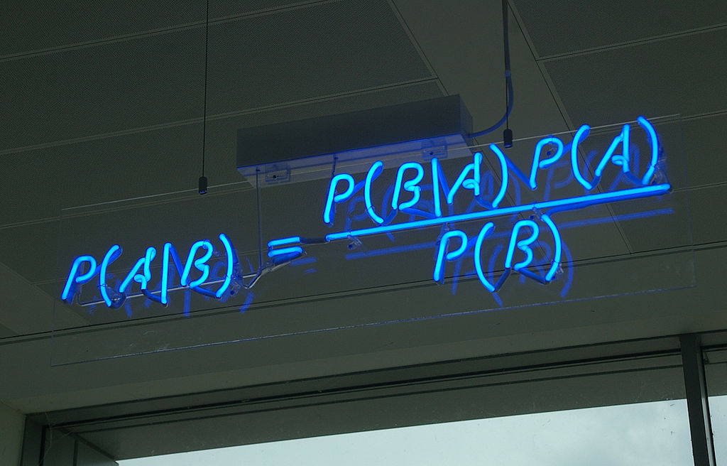

## Bayes theorem and old western

The following is an abridged version of the same story detailed on [page 155 of **The Cult of Statistical Significance**](https://books.google.com/books?id=JWLIRr_ROgAC&pg=PA155#v=onepage&q&f=false):

Dolores arrives at Sweetwater town trying to find out how Arnold died. Without a body to inspect, classical inference is of little help to her:

Classical hypothesis testing evaluates the hypothesis “Arnold was hanged” based on the likelihood of the outcome of the hypothesis. Usually it is impossible to escape death if you are hanged (unless you are in an old western), so the hypothesis is not implausible.

Then Dolores remembers he could also have caught pneumonia, or a bullet; each of those hypotheses cannot be rejected either. With a millions ways to die in the west, she is left scatching her head.

Fisher’s test evaluates the probability of Arnold is dead, given that he was hanged ($P(\mbox{D}|\mbox{H})$). What she wants to know is the opposite: the probability of he hanged, given that he is now dead ($P(\mbox{H}|\mbox{D})$).

### Bayes to the rescue

If she understands Bayes theorem, and some context of the world they live in, things can become easier.

In a world where people die from dehydration, cattle stampedes, bullet wounds, flu, and cardiac arrest, being dead is very weak evidence that the person was hanged. When the probability of being hanged is low compared to other ailments to start with, the probability of him dying from hanging, after knowing the outcome, can still be small.

#### But wait, there’s more

It is not coincidental that the author of the book chose to name the hypothesis “hanging”, and data “death”. But we don’t have to. We can in fact calculate the probability of each hypothesis.

$$P(\mbox{H}=i|\mbox{D}) = \frac{P(\mbox{D}|\mbox{H}=i)P(\mbox{H}=i)}{P(\mbox{D})}$$

Hence we know the ratio of the probability of any two hypothesis, ex post facto, quite easily:

$$\frac{P(\mbox{H}=i|\mbox{D})}{P(\mbox{H}=j|\mbox{D})}
= \frac{P(\mbox{D}|\mbox{H}=i)P(\mbox{H}=i)}{P(\mbox{D})} \frac{P(\mbox{D})}{P(\mbox{D}|\mbox{H}=j)P(\mbox{H}=j)}
= \frac{P(\mbox{D}|\mbox{H}=i)P(\mbox{H}=i)}{P(\mbox{D}|\mbox{H}=j)P(\mbox{H}=j)}$$

That is,

$$P(\mbox{H}=i|\mbox{D}) \propto P(\mbox{D}|\mbox{H}=i)P(\mbox{H}=i)$$

and $P(\mbox{D})$ is a normalizing constant that does not vary with your hypothesis.

Knowing the probability sums to 1,

$$P(\mbox{D}) = \sum_i P(\mbox{D}|\mbox{H}=i)P(\mbox{H}=i)$$

### Naming conventions

We call the $P(\mbox{H})$ the prior (prior belief, before observing the data), $P(\mbox{H}|\mbox{D})$ the posterior, and $P(\mbox{D}|\mbox{H})$ the likelihood.

Posterior is proportional to the likelihood times the prior.

Common notations:

- $\Theta$ for parameter of interest
- $Y$ for random event observed
- $\pi(\theta)$ the prior
- $f(y|\theta)$ the likelihood
- $\pi(\theta|y)$ the posterior

# Bayesian Inference

The primary examples where you want to determine properties of a distribution given only the unnormalized density come from Bayesian inference. Suppose you observe data $y_1, ..., y_n$ with density $f(y|\theta)$ indexed by a parameter $\theta$. A typical approach is to view $\theta$ as a fixed unknown truth you want to determine and and estimate by maximum likelihood

$$\max_\theta f_\theta(y_1, ..., y_n)$$
Instead, a bayesian approach views the parameter as having a distribution when conditioned on the data, and look to make inference about the posterior density, $\pi(\theta|y_1, ..., y_n)$. Noting that $f_\theta(y) = f(y|\theta)$ and applying bayes rule twice:
$$\pi(\theta|y_1, ..., y_n) = \frac{p(\theta, y_1, ..., y_n)}{p(y_1, ..., y_n)} = \frac{f(y_1, ..., y_n|\theta)\pi(\theta)}{p(y_1, ..., y_n)}$$
In the case of $y_i$’s being iid samples, as the sample size increases, the shape of the posterior is increasingly dominated by the likelihood.

The denominator, i.e., the marginal probability of the data
$$p(y_1, ..., y_n) = \int p(\theta, y_1, ..., y_n)\mathrm{d}\theta = \int f(y_1, ..., y_n|\theta)\pi(\theta)\mathrm{d}\theta$$

is the normalizing constant for the posterior distribution and is often an intractable integral. We can apply importance sampling to the unnormalized posterior density
$$f(y_1, ..., y_n|\theta)\pi(\theta)$$

### Example 1

Suppose $X_1, ..., X_n \sim \mathrm{Binomial}(10, \theta)$ where $\theta \in (0, 1)$ has a $\mathrm{Beta}(5, 3)$ prior density:
$$\pi(\theta) = \frac{\Gamma(8)}{\Gamma(5)\Gamma(3)}\theta^4(1-\theta)^2$$
We want to estimate the mean of the posterior distribution: $\int\theta\pi(\theta|x_1, ..., x_n)\mathrm{d}\theta$. Take the (proposal) density function g in importance sampling to be $\mathrm{Beta}(\alpha, \beta)$ density, where
$$\alpha = c\bar{X}\\
\beta = c(10 - \bar{X})$$
where $\bar{X}$ is the sample mean, and c is a positive constant. This will ensure that g is peaked near the MLE $\bar{X}/10$, where the posterior distribution should have a lot of mass. The larger c is, the more sharply peaked around $\bar{X}/10$ will be. We will tune c to minimize the variance of the estimate.

Likelihood:

$$\begin{aligned}
f(x_1, ... , x_n|\theta)
&= \prod_{i=1}^nf(x_i|\theta)\\
&= \prod_{i=1}^n\binom{10}{x_i}\theta^{x_i}(1-\theta)^{10-x_i}\\
&\propto \theta^{\sum x_i}(1-\theta)^{10-\sum x_i}\\
&= \theta^{n\bar{x}}(1-\theta)^{n(10-\bar{x})}\\
\end{aligned}$$

Posterior:

$$\begin{aligned}
\pi(\theta|x_1, ... , x_n)
&\propto f(x_1, ... , x_n|\theta) \pi(\theta)\\
&\propto \theta^{n\bar{x}}(1-\theta)^{n(10-\bar{x})} \pi(\theta)\\
&= \theta^{n\bar{x}}(1-\theta)^{n(10-\bar{x})} \frac{\Gamma(8)}{\Gamma(5)\Gamma(3)}\theta^4(1-\theta)^2\\
&\propto \theta^{n\bar{x}}(1-\theta)^{n(10-\bar{x})} \theta^4(1-\theta)^2\\
&= \theta^{n\bar{x}+4}(1-\theta)^{n(10-\bar{x})+2}
\end{aligned}$$

The log of this quantity is
$${(n\bar{x}+4)}\log(\theta) + {(n(10-\bar{x})+2)}\log(1-\theta)$$

The following code illuistrate choices of different trial/proposal densities to approximate posterior.

```r
log.prior <-  function(theta) {
  4 * log(theta) + 2 * log(1 - theta)
}
log.likelihood <-  function(data, theta) {
  n <- length(data)
  sum(data) * log(theta) + n * (10 - mean(data)) * log(1 - theta)
}
log.posterior <-  function(data, theta) {
  log.prior(theta) + log.likelihood(data, theta)
}
log.g <- function(data, theta, C) {
   dbeta(theta, C * mean(data), C * (10 - mean(data)), log = TRUE)
}
data = rbinom(10, 10, .4)
theta.seq <- seq(0,1,0.001)
log.prior.eval <- log.prior(theta.seq)
log.likelihood.eval <- log.likelihood(data, theta.seq)
log.posterior.eval <- log.posterior(data, theta.seq)
plot(theta.seq, exp(log.prior.eval-max(log.prior.eval)),
     type = 'l', xlab = "theta", ylab = "density up to normalization",
     main = "Prior and posterior densities")
lines(theta.seq, exp(log.likelihood.eval-max(log.likelihood.eval)), col = 2)
```

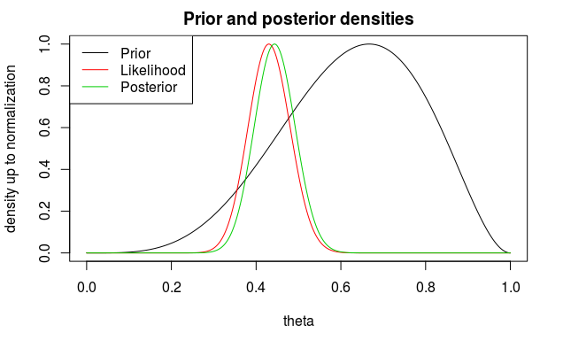

```r
lines(theta.seq, exp(log.posterior.eval-max(log.posterior.eval)), col = 3)
legend("topleft", legend = c("Prior", "Likelihood", "Posterior"),
       lty = 1, col = c(1:3))
```

```r
C.choice1 <- 1
C.choice2 <- 10
C.choice3 <- 50
log.g1.eval <- log.g(data, theta.seq, C.choice1)
log.g2.eval <- log.g(data, theta.seq, C.choice2)
log.g3.eval <- log.g(data, theta.seq, C.choice3)
plot(theta.seq, exp(log.posterior.eval-max(log.posterior.eval)),
     type = 'l', xlab = "theta", ylab = "density up to normalization",
     main = "Posterior and proposal densities", col = 3, lwd = 2)
lines(theta.seq, exp(log.g1.eval-max(log.g1.eval)), col = 4, lty = 2)
```

```r
lines(theta.seq, exp(log.g2.eval-max(log.g2.eval)), col = 4, lty = 3)
lines(theta.seq, exp(log.g3.eval-max(log.g3.eval)), col = 4, lty = 4)
```

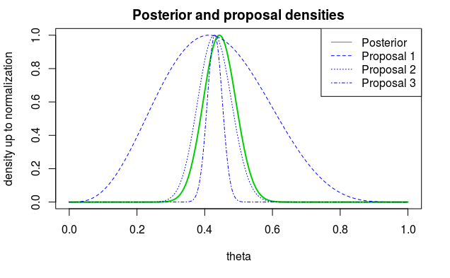

```r
legend("topright", legend = c("Posterior", "Proposal 1", "Proposal 2", "Proposal 3"),
       lty = 1:4, col = c(3,4,4,4))
```

The bettter our proposal density approximates the posterior density, the less variable the importance weight $\pi(\theta|data)/g(\theta)$, hence the more accurate our importance sampling estimates will be.

The following R code executes the importance sampling:

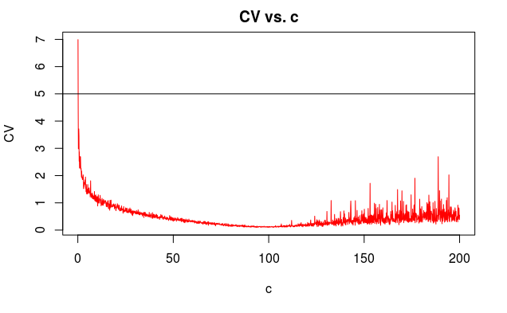

```r
# X is the data, res is the number of monte carlo samples,
# C is the tuning parameter for the g distribution
IS <- function(X, C, n)
{
  # sample size
  n <- length(X)
  # log posterior derived above
  log.posterior <-  function(theta) {
    (sum(X) + 4) * log(theta) + (n * (10 - mean(X)) + 2) * log(1 - theta)
  }
  # log trial (proposal) density, g
  log.g <- function(theta) {
    dbeta(theta, C * mean(X), C * (10 - mean(X)), log = TRUE)
  }

  # log importance function
  log.w <- function(theta) {
    log.posterior(theta) - log.g(theta)
  }

  # generate from the trial (proposal) distribution
  U <- rbeta(n, C * mean(X), C * (10 - mean(X)))

  # calculate the list of log.w values
  LP <- log.w(U)

  # factor out the largest value to prevent numerical underflow
  w <- max(LP)
  LP <- LP - w

  # importance sampling estimate
  I <- mean(exp(LP) * U) / mean(exp(LP))

  # calculate CV
  CV <- sqrt( var( exp(LP) / mean(exp(LP) ) ) )

  # calculate s.e. of the IS estimate
  Z = exp(LP) * U / mean(exp(LP))
  sig.sq <- var( Z )
  se <- sqrt( sig.sq / n )

  # return the 95 percent confidence interval for the estimate
  return(list(lower = I - 1.96 * se, upper = I + 1.96 * se, CV = CV))
}
# Generate 100 binomial(10,.4) random variables
X = rbinom(100, 10, .4)
## calculate CV and var(E(theta|X))
## over a grid of values for alpha
C <- seq(.1, 200, length = 2000)
A <- matrix(0, 2000, 2)
for (j in 1:2000) {
  output <- IS(X, C[j], 1000)
  CV <- output$CV
  V <- (output$upper - output$lower) / 3.92
  A[j, ] <- c(CV, V)
}
# see where CV is low enough
plot(C, A[, 1], ylab = "CV", xlab = "c",
     main = "CV vs. c", col = 2, type = "l")
abline(h = 5)
```

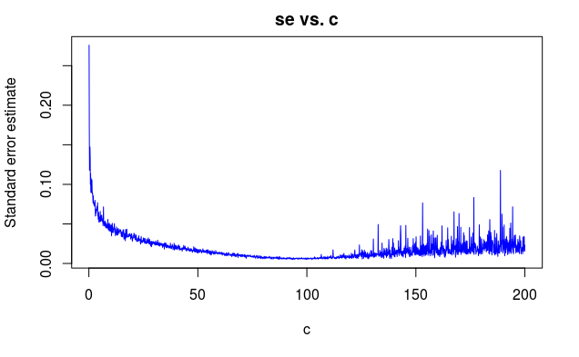

```r
# standard error estimates
plot(C, A[, 2], xlab = "c", ylab = "Standard error estimate",
     main = "se vs. c", col = 4, type = "l")
```

```r
# The final confidence interval
IS(X, C[which.min(A[, 2])], 1000)[1:2]
```

```
$lower
[1] 0.3804076

$upper
[1] 0.4032227
```

## Q&A

- Q: Do I have to perform importance sampling for posterior inference?
- A: No. Any method that deals with distributions with unknown normalizing constants will be useful. In this course we covered rejection sampling and importance sampling, both of which are suitable tools.

.

.

.